# Homework #1

Anthony Conrardy

2024-09-22

## Geometric Transformation of Shapes Using Matrix Multiplication

### Context:

In computer graphics and data visualization, geometric transformations are fundamental. These transformations, such as translation, scaling, rotation, and reflection, can be applied to shapes to manipulate their appearance.

### Task:

Create a simple shape (like a square or triangle) using point plots in R. Implement R code to apply different transformations (scaling, rotation, reflection) to the shape by left multiplying a transformation matrix by each of the point vectors. Demonstrate these transformations through animated plots.

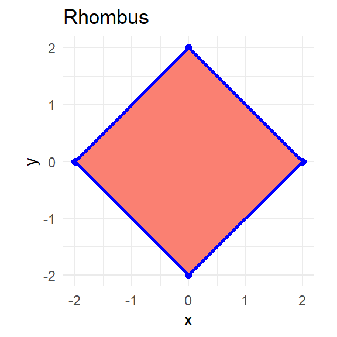

```r
# Define the coordinates for the vertices of the rhombus
x <- c(0,2,0,-2)
y <- c(2,0,-2,0)
rhombus <- data.frame(x,y)

# Create Rhombus Plot
ggplot(rhombus, aes(x,y)) +
  geom_point(size=2, color = 'blue') +
  geom_polygon(aes(x,y), fill = 'salmon', color = 'blue', linewidth=1) +
  theme_minimal() +
  coord_equal() +
  labs(title = "Rhombus")
```

```r
rhombus_matrix <- as.matrix(rhombus) # Convert the data frame to a matrix
scale_factor <- 2 # Can select whatever factor
scaling_matrix <- matrix(c(scale_factor,0,0,scale_factor), ncol=2) # Create the scaling matrix
scaling_matrix
```

```
##      [,1] [,2]
## [1,]    2    0
## [2,]    0    2
```

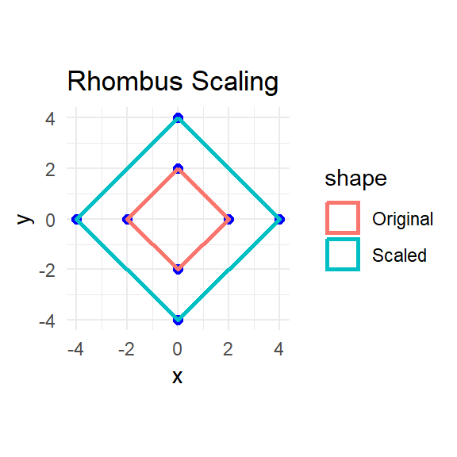

```r
scaled_rhombus <- t(apply(rhombus_matrix,1, function(row) scaling_matrix %*% matrix(row, ncol = 1)))
scaled_rhombus_df <- as.data.frame(scaled_rhombus) # Convert matrix to dataframe to use ggplot
colnames(scaled_rhombus_df) <- c('x', 'y')
# Group the shapes into one dataframe
both_rhombus <- rbind(
  data.frame(rhombus, shape='Original'),
  data.frame(scaled_rhombus_df, shape='Scaled')
)

ggplot(both_rhombus, aes(x,y, color=shape)) +
  geom_point(size=2, color = 'blue') +
  geom_polygon(aes(group=shape), fill = NA, linewidth=1) +
  theme_minimal() +
  coord_equal() +
  labs(title = "Rhombus Scaling")
```

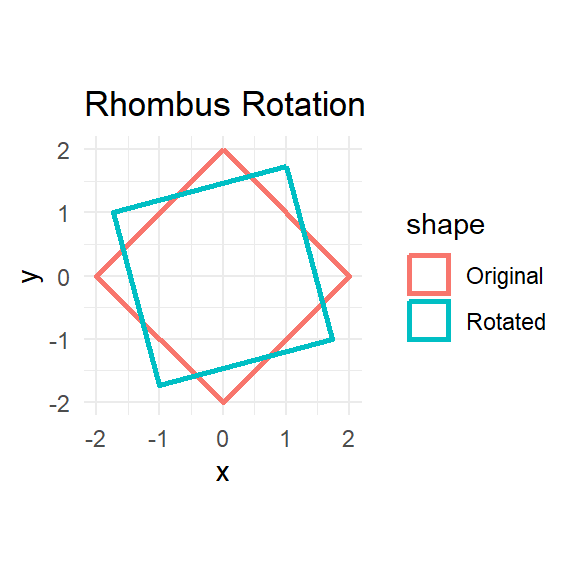

```r
rotation_angle <- -30 # Rotation angle can be changed as needed.
radians <- rotation_angle * pi/180
# Rotation Matrix
rotation_matrix <- matrix(c(cos(radians), sin(radians),
                            -sin(radians), cos(radians)), ncol = 2)
# Rotate the Matrix
rotated_matrix <- t(apply(rhombus_matrix, 1, function(row) rotation_matrix %*% matrix(row, ncol = 1)))

rotated_rhombus_df <- as.data.frame(rotated_matrix) # Convert matrix to data frame to use ggplot
colnames(rotated_rhombus_df) <- c('x', 'y')
# Group the shapes into one data frame
both_rhombus_r <- rbind(
  data.frame(rhombus, shape = 'Original'),
  data.frame(rotated_rhombus_df, shape = 'Rotated')
)
ggplot(both_rhombus_r, aes(x,y, color = shape)) +
  geom_polygon(aes(group = shape), fill=NA, linewidth=1) +
  theme_minimal() +
  coord_equal() +
  labs(title = 'Rhombus Rotation')
```

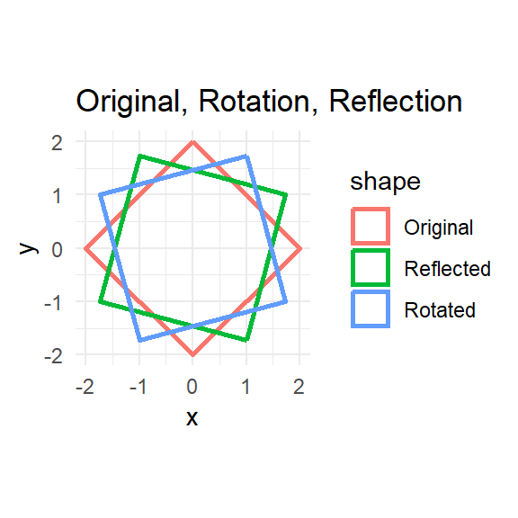

```r
# Create the reflection matrix across the x-axis
reflection_matrix <- matrix(c(1,0,0,-1), ncol = 2)

reflected_rhombus <- t(apply(rotated_matrix, 1, function(row) reflection_matrix %*% matrix(row, ncol = 1)))

reflected_rhombus_df <- as.data.frame(reflected_rhombus)
colnames(reflected_rhombus_df) <- c('x', 'y')

# Group the shapes into one data frame
both_rhombus_ref <- rbind(
  data.frame(rhombus, shape = 'Original'),
  data.frame(rotated_rhombus_df, shape = 'Rotated'),
  data.frame(reflected_rhombus_df, shape = 'Reflected')
)
ggplot(both_rhombus_ref, aes(x, y, color = shape)) +
  geom_polygon(aes(group = shape), fill = NA, linewidth = 1) +
  theme_minimal() +
  coord_equal() +
  labs(title = "Original, Rotation, Reflection")
```

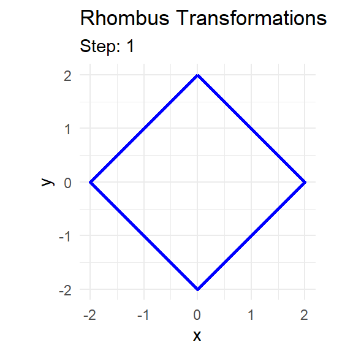

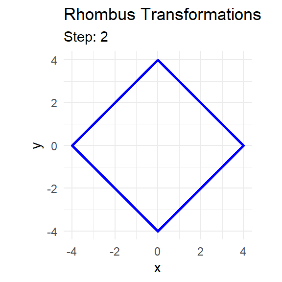

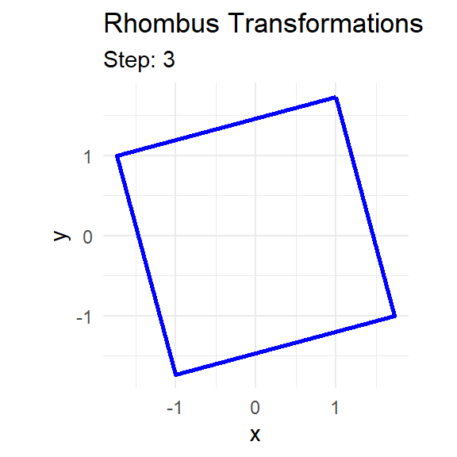

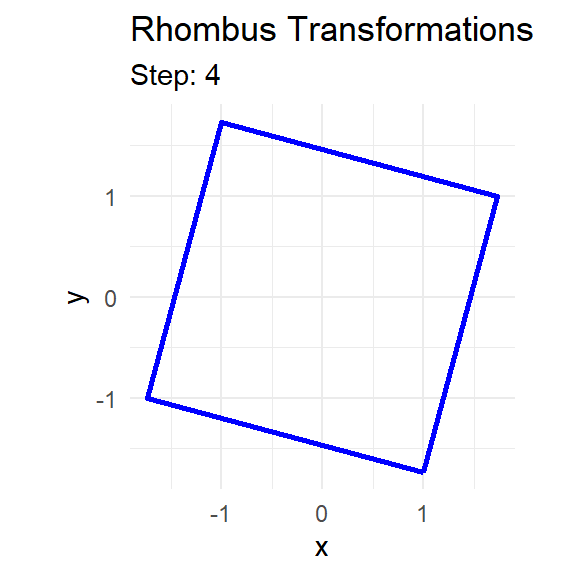

```r
animation_frames <- list(rhombus,
                         scaled_rhombus_df,
                         rotated_rhombus_df,
                         reflected_rhombus_df)
for (i in 1:length(animation_frames)){
  pr <- ggplot(animation_frames[[i]], aes(x,y)) +
    geom_polygon(fill=NA, color = 'blue', linewidth = 1) +
    theme_minimal() +
    coord_equal() +
    labs(title = "Rhombus Transformations",
         subtitle = paste('Step:',i))
  print(pr)
  Sys.sleep(0.5)
}
```

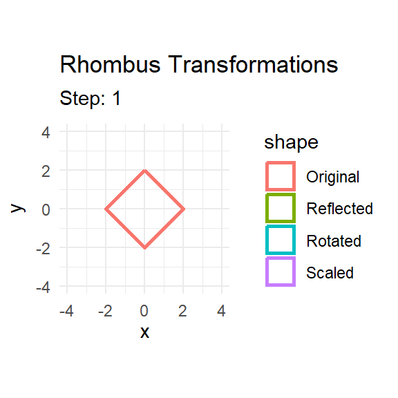

```r
all_steps_data <- rbind(
    transform(rhombus, step = 1, shape = "Original"),
    transform(scaled_rhombus_df, step = 2, shape = "Scaled"),
    transform(rotated_rhombus_df, step = 3, shape = "Rotated"),
    transform(reflected_rhombus_df, step = 4, shape = "Reflected")
)

animation <- ggplot(all_steps_data, aes(x, y, color = shape)) +
    geom_polygon(fill = NA, linewidth = 1) +
    theme_minimal() +
    coord_equal() +
    labs(title = "Rhombus Transformations", subtitle = "Step: {closest_state}") +
    transition_states(step, transition_length = 2, state_length = 1) +
    ease_aes('sine-in-out')
# anim_save('rhombus_transform.gif', animation)
animate(animation)
```

## Matrix Properties and Decompostion

### Context

Every time you upload a photo to social media, algorithms often compress your image to reduce file size without significantly degrading quality. One of the key techniques used in this process is Singular Value Decomposition (SVD), which is another form of matrix factorization.

### Task

Write an R function that performs Singular Value Decomposition (SVD) on a grayscale image (which can be represented as a matrix). Use this decomposition to compress the image by keeping only the top k singular values and their corresponding vectors. Demonstrate the effect of different values of k on the compressed image’s quality. You can choose any open-access grayscale image that is appropriate for a professional program.

Instructions:  
1) Read an Image: Convert a grayscale image into a matrix.  
2) Perform SVD: Factorize the image matrix into using R’s built-in svd() function.  
3) Compress the Image: Reconstruct the image using only the top k singular values and vectors.  
4) Visualize the Result: Plot the original image alongside the compressed versions for various values of k (e.g., k = 5, 20, 50).

```r
# Correct raw file URL
url <- "https://raw.githubusercontent.com/Aconrard/DATA605/refs/heads/main/bird.png"

# Download the raw content
image_path <- getBinaryURL(url)

# Convert the image into a matrix for SVD
image_read <- readPNG(image_path)
# Rotate the image 90 degrees clockwise
image_read <- t(apply(image_read, 2, rev))

# Perform SVD
image_svd <- svd(image_read)

# U, S, and V Decomposed Matrices
U <- image_svd$u
S <- diag(image_svd$d)
V <- image_svd$v

# Compress the image by keeping the top 5 singular values for compression
k <- 5
compressed_image_5 <- U[,1:k] %*% S[1:k,1:k] %*% t(V[,1:k])
# Compress the image by keeping the top 20 singular values for compression
k <- 20
compressed_image_20 <- U[,1:k] %*% S[1:k,1:k] %*% t(V[,1:k])
# Compress the image by keeping the top 50 singular values for compression
k <- 50
compressed_image_50 <- U[,1:k] %*% S[1:k,1:k] %*% t(V[,1:k])
```

### Visualize the results of original, k=5, k=20, and k=50 images

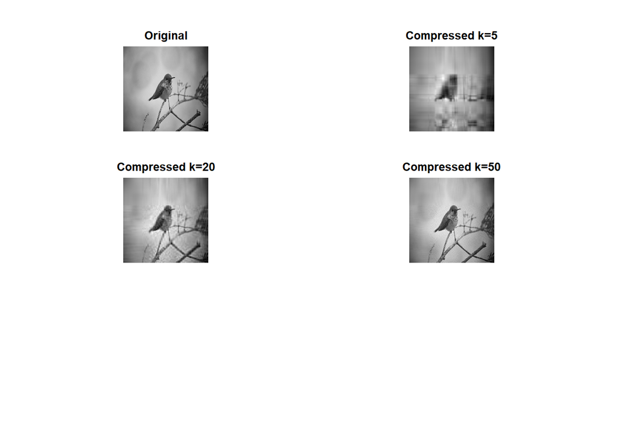

## Matrix Rank, Properties, and Eigenspace

### Determine the Rank of the Given Matrix

$$A = \begin{bmatrix} 2 & 4 & 1
& 3\\
-2 & -3 & 4 & 1\\
5 & 6 & 2 & 8\\
-1 & -2 & 3 & 7\\
\end{bmatrix}$$

Find the rank of the matrix. Explain what the rank tells us about the linear independence of the rows and columns of matrix. Identify if there are any linear dependencies among the rows or columns.

First let us find the rank of the of matrix A in R:

```r
A <- matrix(c(2,4,1,3,-2,-3,4,1,5,6,2,8,-1,-2,3,7), nrow = 4, byrow = TRUE)
qr_A <- qr(A)
rank_A <- qr_A$rank
print(rank_A)
```

```
## [1] 4
```

The rank tells us the number of linearly independent rows are in the matrix. Full rank indicates that no rows can be created by adding or subtracting multiples of the other rows. Less than full rank indicates that there is at least one linearly dependent row and column. Since the rank = 4 and it is not less than the number of rows or columns, there are no linear dependencies.

### Matrix Rank Boundaries

Given a m x n matrix, where m > n, determine the maximum and minimum rank, assuming that the matrix is non-zero. This indicates that the matrix has more rows than columns, so the maximum rank is the smaller number of the two numbers m and n, which in this case is n. Each column can contribute one linearly independent vector to the column space, so if each row is linearly independent, the maximum rank is n. This also indicates that at least one of the rows is linearly dependent.

Proof: If the rank of a matrix is the maximum number of linearly independent rows, which must be less than or equal to n,

and

The row space of the matrix is set of all possible linear combinations of the rows of the matrix,

and

The linear independent rows of the matrix form the basis of the matrix, or span the space.

and

The dimension of a vector space is the number of vectors in any basis for that space.

then

The rank of the matrix is the number of linearly independent rows, and these form the basis of the row (or column) space, the rank now equals the dimension of the row space.

$$C = \begin{bmatrix} 1 & 2 & -1\\
3 & -1 & 2\\
2 & 4 & -2\\
5 & 3 & 0\\
\end{bmatrix}$$

```r
C <- matrix(c(1,2,-1,3,-1,2,2,4,-2,5,3,0), nrow = 4, byrow = TRUE)
reduced_echelon <- rref(C)
print(reduced_echelon)
```

```
##      [,1] [,2]       [,3]
## [1,]    1    0  0.4285714
## [2,]    0    1 -0.7142857
## [3,]    0    0  0.0000000
## [4,]    0    0  0.0000000
```

```r
qr_C <- qr(C)
rank_C <- qr_C$rank
print(rank_C)
```

```
## [1] 2
```

The maximum rank for this 4 x 3 matrix would be 3, but this example gives a rank 2 because two of the rows are linearly dependent on one or both of the other rows.

### Rank and Row Reduction

Determine the rank of matrix B. Perform a reduction on matrix B and describe how it helps in finding the rank. Discuss any special properties of matrix B.

$$B = \begin{bmatrix} 2 & 5 & 7\\
4 & 10 & 14\\
1 & 2.5 & 3.5\\
\end{bmatrix}$$

We will quickly reduce the matrix using the pracma package and determine the rank by identifying the number of linearly independent rows. The maximum rank for this matrix is 3, but we will see. However, a quick scan sees that row 1 is 2 times row 3, and row 2 is 4 times row 3.

```r
B <- matrix(c(2,5,7,4,10,14,1,2.5,3.5), nrow = 3, byrow = TRUE)
reduced_echelon_b <- rref(B)
print(reduced_echelon_b)
```

```
##      [,1] [,2] [,3]
## [1,]    1  2.5  3.5
## [2,]    0  0.0  0.0
## [3,]    0  0.0  0.0
```

### Compute Eigenvalues and Eigenvectors

Find the eigenvalues and eigenvectors of the matrix. Write out the characteristic polynomial and show your solution step by step. After finding the eigenvalues and eigenvectors, verify that the eigenvectors are linearly independent. If they are not, explain why.

$$A = \begin{bmatrix} 3 & 1 & 2\\
0 & 5 & 4\\
0 & 0 & 2\\
\end{bmatrix}$$

$$det(A - \lambda I) = \begin{bmatrix}
3-\lambda & 1 & 2\\
0 & 5-\lambda & 4\\
0 & 0 & 2-\lambda\\
\end{bmatrix}=0$$

Because the matrix is an upper diagonal matrix, the determinant is simply the product of the diagonal values, which gives us our characteristic polynomial in root form:

$$(3-\lambda)(5-\lambda)(2-\lambda)=0$$

So our eigenvalues are 2, 3, and 5. Substituting the eigenvalues back into the equation:
$$(A - λI)x = 0$$
We get the following matrices to calculate the associated eigenvectors:

$$A - 2I \begin{bmatrix} 1 & 1 & 2\\
0 & 3 & 4\\
0 & 0 & 0\\
\end{bmatrix}\begin{bmatrix} x1\\
x2\\
x3\end{bmatrix}=0$$
Assigning x3=1, we get x1=-2/3, and x2=-4/3, creating eigenvector:
$$\begin{bmatrix} -2/3\\
-4/3\\
1\end{bmatrix}$$

$$A - 3I \begin{bmatrix} 0 & 1 & 2\\
0 & 2 & 4\\
0 & 0 & -1\\
\end{bmatrix}\begin{bmatrix} x1\\
x2\\
x3\end{bmatrix}=0$$
x3=0, we get x2=0, and x1=1, creating eigenvector:
$$\begin{bmatrix} 1\\
0\\
0\end{bmatrix}$$

$$A - 5I \begin{bmatrix} -2 & 1 & 2\\
0 & 0 & 4\\
0 & 0 & -3\\
\end{bmatrix}\begin{bmatrix} x1\\
x2\\
x3\end{bmatrix}=0$$
x3=0, we can set x2=1, and x1=1/2, creating eigenvector:
$$\begin{bmatrix} 1/2\\
1\\
0\end{bmatrix}$$

To determine if the eigenvectors are linearly independent, we set each eigenvector as a column in a matrix and then find the determinant.
$$det\begin{bmatrix} 1 & 1/2 & -2/3\\
0 & 1 & -4/3\\
0 & 0 & 1\\
\end{bmatrix}=1$$

Since this is an upper triangular matrix, the determinant is a product of the diagonal values. And, since the determinant value is not equal to zero, the eigenvectors are linearly independent.

### Diagonalization of Matrix

Determine if matrix can be diagonalized. If it can, find the diagonal matrix and the matrix of eigenvectors that diagonalizes. Discuss the geometric interpretation of the eigenvectors and eigenvalues in the context of transformations. For instance, how does matrix stretch, shrink, or rotate vectors in?

We must check to see if the matrix can be diagonalized. If all eigenvalues are distinct, then the matrix is guaranteed to be diagonalizable. If the eigenvalues are not distinct, the matrix can still be diagonalizable if their eigenvectors for the basis of R3. Let’s check to see if all eigenvalues are distinct.

```r
E <- matrix(c(3,1,2,0,5,4,0,0,2), nrow = 3, byrow = TRUE)
eigen_E <- eigen(E)
eigen_distinct <- unique(eigen_E$values)
print(eigen_E$values)
```

```
## [1] 5 3 2
```

```r
print(eigen_distinct)
```

```
## [1] 5 3 2
```

In this case we see that all eigenvalues are distinct, and the number of distinct eigenvalues equal the rank of the matrix.

In the setting of a transformation, an eigenvector will not change direction, but may change in magnitude (scaling). So, in other words, after a transformation the eigevctor will only change in size, compressed or lengthened. On the other hand, the eigenvalues associated with the eigenvector is how much the eigenvector is stretched or lengthened (scaling) during the transformation. A positive value greater than 1 indicates a lengthening, a positive value less than one indicates compression, a negative value less than -1 indicates flipping (reflection and stretching), a negative value greater than -1 indicates flipping and compression, and an eigenvalue equal to 1 indicates no change at all during the transformation.

## Project: Eigenfaces from the LFW (Labeled Faces in the Wild) Dataset

### Context:

Eigenfaces are a popular application of Principal Component Analysis (PCA) in computer vision. They are used for face recognition by finding the principal components (eigenvectors) of the covariance matrix of a set of facial images. These principal components represent the “eigenfaces” that can be combined to approximate any face in the dataset.

### Task:

Using the LFW (Labeled Faces in the Wild) dataset, build and visualize eigenfaces that account for 80% of the variability in the dataset. The LFW dataset is a well-known dataset containing thousands of labeled facial images, available for academic research. ***

#### Preprocess the images from the download

```r
folder_path <- "D:/Documents/DATA 605/LFW/lfw-deepfunneled/lfw-deepfunneled/1-Photos"

# Function to preprocess images from a folder
preprocess_images_from_folder <- function(folder_path, num_images = 100, img_width=64, img_height=64) {
  # Get a list of image files in the folder
  image_files <- list.files(folder_path, full.names = TRUE)

  # Select a subset of images if num_images is specified
  if (length(image_files) > num_images) {
    image_files <- image_files[1:num_images]
  }

  # Preprocess each image and store the vectors in a list
  image_vectors <- lapply(image_files, function(image_path) {
    # Load the image
    img <- load.image(image_path)

    # Error handling: Check if the image loaded correctly
    if (is.null(img)) {
      stop(paste("Error loading image:", image_path))
    }

    # Convert to grayscale
    img_gray <- grayscale(img)

    # Resize the image
    img_resized <- resize(img_gray, img_width, img_height)

    # Flatten the image into a vector
    img_vector <- as.vector(img_resized)

    return(img_vector)
  })

  # Convert the list of vectors to a matrix
  image_matrix <- do.call(rbind, image_vectors)

  return(image_matrix)
}

# Example usage:
image_matrix <- preprocess_images_from_folder(folder_path, num_images = 50) # Process 50 images

# Now 'image_matrix' contains the pre-processed data for the images
print(dim(image_matrix)) # Check the dimensions of the matrix
```

```
## [1]   44 4096
```

#### Compute the PCA and determine the number of principal components accounting for 80% variance

```r
# Perform the PCA
pca <- prcomp(image_matrix, center = TRUE, scale = FALSE)
# Calculate variance explained by each principal component
var_explained <- pca$sdev^2/sum(pca$sdev^2)
# Calculate the cumulative variance explained
cum_var <- cumsum(var_explained)
# Find the number of principal components for 80% variance
num_pcs <- which(cum_var >= 0.8)[1]
```

```
## Number of PCs for 80% variance: 17
```

```
## The variances of the 17 principal components are: 0.2413595 0.0994658 0.070718 0.06049256 0.04578111 0.03892932 0.0336106 0.03033141 0.02917732 0.02488766 0.02248594 0.02160951 0.01903261 0.01726547 0.01707714 0.0161792 0.01478814
```

```
## The sum of the variances of the 17 principal components is: 0.8031913
```

For the images we used, there are 17 principal components that account for 80% of the variability.

#### Visualize the the first few eigenfaces (principal components) and discuss their signficance

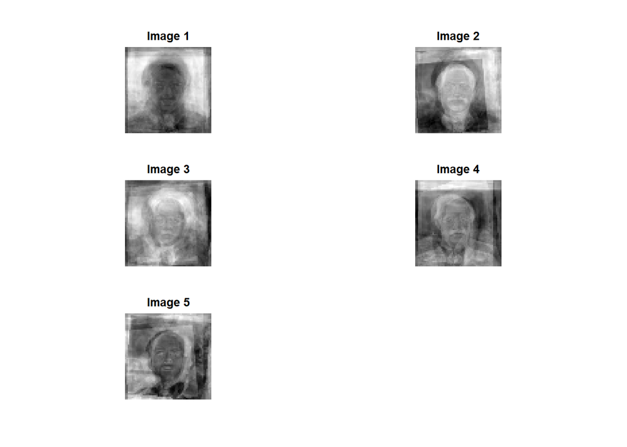

```r
eigenfaces <- pca$rotation
# Set up plotting parameters

par(mfrow = c(3, 2), mar = c(2, 2, 2, 2), oma = c(2, 2, 2, 2))

for (i in 1:5) {
  eigenface <- matrix(eigenfaces[, i], nrow = 64, ncol = 64)

  # Rotate the image 180 degrees by flipping both rows and columns
  rotated_eigenface <- eigenface[64:1, 64:1]

  # Display the image
  image(rotated_eigenface, col = gray((0:255)/255), main=paste("Image", i), axes = FALSE, asp=1)
}

par(mfrow = c(1,1))
```

The eigenfaces (or principal components) have both light and dark regions that correspond to the positive and negative weights of the vectors. Brighter areas indicate features that tend to vary together, while dark areas represent features that vary in opposition to the brighter areas. The earlier eigenfaces usually capture the most significant variations, while the others tend to contribute much less. In our case, the first 9 values account for about 65% of the variance while the remaining 8 values capture an additional 15%. It is hoped that these principal components can be used to approximately represent any face in our data set.

Here are the reconstructed issues created from the eigenfaces.

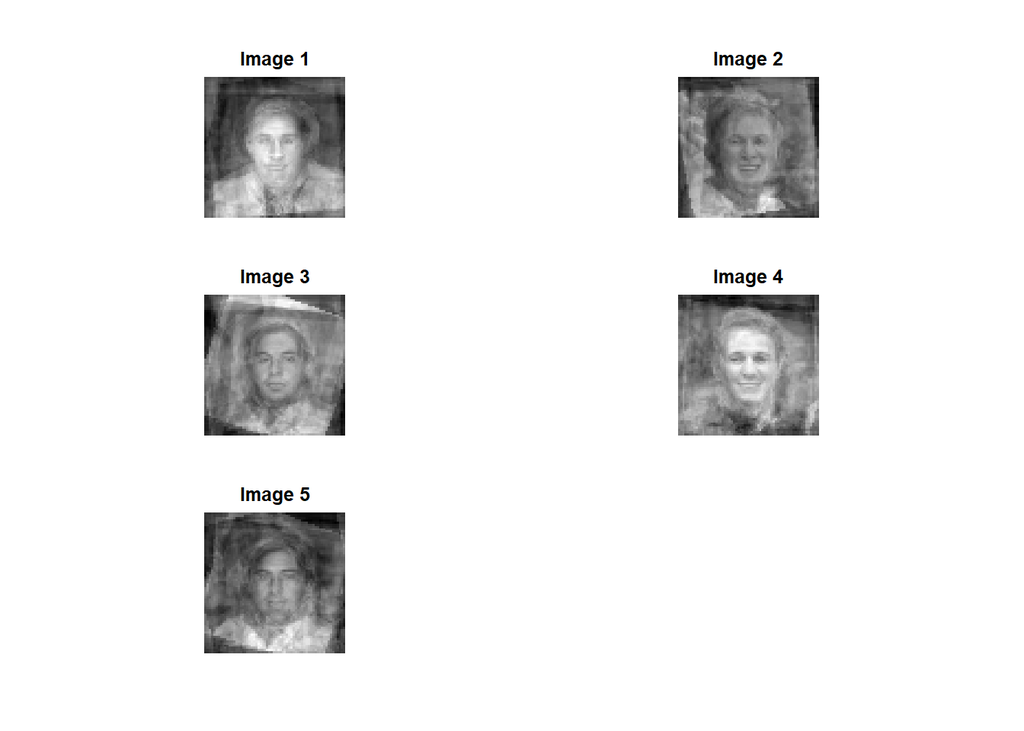

```r
# Select the first 5 images from the PCA transformed data
pca_data_subset <- pca$x[1:5, 1:num_pcs]

# Reconstruct the images
reconstructed_images <- pca_data_subset %*% t(pca$rotation[, 1:num_pcs])

# Add the mean back (since we centered during PCA)
reconstructed_images <- scale(reconstructed_images, center = -pca$center, scale = FALSE)

# Set up plotting parameters
par(mfrow = c(3, 2), mar = c(2, 2, 2, 2), oma = c(2, 2, 2, 2))

# Visualize the reconstructed images
for (i in 1:5) {
  # Reshape the image vector back to a matrix
  reconstructed_image <- matrix(reconstructed_images[i, ], nrow = 64, ncol = 64)

  # Reflect the image around the y-axis
  reflected_image <- reconstructed_image[, 64:1]

  # Display the reconstructed image (as grayscale)
  image(reflected_image, col = gray((0:255)/255), main = paste("Image", i), axes = FALSE, asp=1)
}
par(mfrow = c(1,1))
```

Here are the corresponding images:

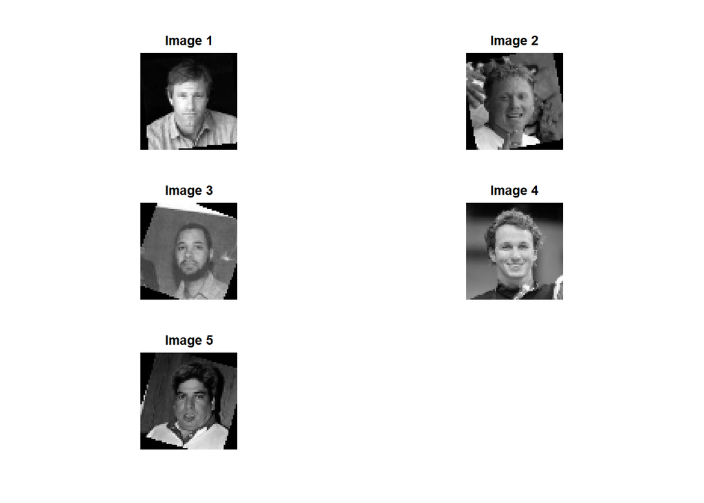

```r
# Set up plotting parameters
par(mfrow = c(3, 2), mar = c(2, 2, 2, 2), oma = c(2, 2, 2, 2))

for (i in 1:5) {
  # Reshape each image vector back to a 64x64 matrix
  image_matrix_reshaped <- matrix(image_matrix[i, ], nrow = 64, ncol = 64, byrow = TRUE)

  # Rotate the image 90 degrees counterclockwise and then flip vertically
  rotated_image <- t(image_matrix_reshaped)[, 64:1]

  # Display the image with correct aspect ratio and enlarged size
  image(rotated_image, col = gray((0:255)/255), main = paste("Image", i), axes = FALSE, asp = 1)
}
par(mfrow = c(1,1))
```